# Class 15: Transcriptomics and the analysis of RNA-Seq

```r
counts <- read.csv("data/airway_scaledcounts.csv", stringsAsFactors = FALSE)
metadata <-  read.csv("data/airway_metadata.csv", stringsAsFactors = FALSE)
```

```r
dim(counts)
```

```
## [1] 38694     9
```

```r
head(counts)
```

```
##           ensgene SRR1039508 SRR1039509 SRR1039512 SRR1039513 SRR1039516
## 1 ENSG00000000003        723        486        904        445       1170
## 2 ENSG00000000005          0          0          0          0          0
## 3 ENSG00000000419        467        523        616        371        582
## 4 ENSG00000000457        347        258        364        237        318
## 5 ENSG00000000460         96         81         73         66        118
## 6 ENSG00000000938          0          0          1          0          2
##   SRR1039517 SRR1039520 SRR1039521
## 1       1097        806        604
## 2          0          0          0
## 3        781        417        509
## 4        447        330        324
## 5         94        102         74
## 6          0          0          0
```

The column of the metadata should match the header/first row of the counts (above).

```r
head(metadata)
```

```
##           id     dex celltype     geo_id
## 1 SRR1039508 control   N61311 GSM1275862
## 2 SRR1039509 treated   N61311 GSM1275863
## 3 SRR1039512 control  N052611 GSM1275866
## 4 SRR1039513 treated  N052611 GSM1275867
## 5 SRR1039516 control  N080611 GSM1275870
## 6 SRR1039517 treated  N080611 GSM1275871
```

```r
colnames(counts)
```

```
## [1] "ensgene"    "SRR1039508" "SRR1039509" "SRR1039512" "SRR1039513"
## [6] "SRR1039516" "SRR1039517" "SRR1039520" "SRR1039521"
```

```r
metadata$id
```

```
## [1] "SRR1039508" "SRR1039509" "SRR1039512" "SRR1039513" "SRR1039516"
## [6] "SRR1039517" "SRR1039520" "SRR1039521"
```

Check for correspondence of matadata and countdata

```r
colnames(counts)[-1] == metadata$id
```

```
## [1] TRUE TRUE TRUE TRUE TRUE TRUE TRUE TRUE
```

Insert “all” to the previous and gives a single answer

```r
all(colnames(counts)[-1] == metadata$id)
```

```
## [1] TRUE
```

First task, find which colums in **counts** correspond to the control conditions (i.e. no drug!). Then we can caluclate the mean count value for each gene. #control.inds <- metadata$dex == "control" -- gives us a TRUE/FALSE response to whether we have a control dex # originally without "control.inds <- metadata$id[control.inds]“, was off by one

```r
control.inds <- metadata$dex == "control"
control.inds <-  metadata$id[control.inds]

head(counts[,control.inds])
```

```
##   SRR1039508 SRR1039512 SRR1039516 SRR1039520
## 1        723        904       1170        806
## 2          0          0          0          0
## 3        467        616        582        417
## 4        347        364        318        330
## 5         96         73        118        102
## 6          0          1          2          0
```

Calculate the mean counts value for all genes

```r
control.mean <- rowSums(counts[,control.inds])/ncol(counts[,control.inds])
names(control.mean) <- counts$ensgene
head(control.mean)
```

```
## ENSG00000000003 ENSG00000000005 ENSG00000000419 ENSG00000000457
##          900.75            0.00          520.50          339.75
## ENSG00000000460 ENSG00000000938
##           97.25            0.75
```

Now do the same thing for the drug treated samples (i.e. *treated* columns)

```r
treated <- metadata[metadata[,"dex"] == "treated",]
treated.mean <- rowSums( counts[ ,treated$id] )/ncol(counts[,treated$id])
names(treated.mean) <- counts$ensgene
```

Combind the mean count values for contro and treated into a new data,frame called meancounts!

```r
meancounts <-  data.frame(control.mean, treated.mean)
meancounts
```

```
##                 control.mean treated.mean
## ENSG00000000003       900.75       658.00
## ENSG00000000005         0.00         0.00
## ENSG00000000419       520.50       546.00
## ENSG00000000457       339.75       316.50
## ENSG00000000460        97.25        78.75
## ENSG00000000938         0.75         0.00
## ENSG00000000971      5219.00      6687.50
## ENSG00000001036      2327.00      1785.75
## ENSG00000001084       755.75       578.00
## ENSG00000001167       527.75       348.25
## ENSG00000001460       226.75       185.50
## ENSG00000001461      3169.50      2701.25
## ENSG00000001497       589.50       519.50
## ENSG00000001561       110.50       106.75
## ENSG00000001617       695.25       543.50
## ENSG00000001626        11.25         8.00
## ENSG00000001629      2146.00      1679.75
## ENSG00000001630      1117.50       895.75
## ENSG00000001631       936.00       826.00
## ENSG00000002016       251.25       173.50
## ENSG00000002079         2.25         3.25
## ENSG00000002330       735.00       678.50
## ENSG00000002549      1249.25      1256.75
## ENSG00000002586      8802.75      8456.50
## ENSG00000002587         1.75         2.25
## ENSG00000002726         1.25         1.75
## ENSG00000002745         9.75         4.75
## ENSG00000002746       125.00       126.00
## ENSG00000002822       385.25       348.00
## ENSG00000002834      7889.00      9618.25
## ENSG00000002919       237.50       270.75
## ENSG00000002933       498.75       527.50
## ENSG00000003056      1962.25      1769.00
## ENSG00000003096       581.25       268.25
## ENSG00000003137       149.25        61.25
## ENSG00000003147         9.00        10.00
## ENSG00000003249       146.50       101.00
## ENSG00000003393       900.00       896.00
## ENSG00000003400       107.00        79.00
```

[output cut: 38640 more lines]

[output not shown]

```r
colSums(meancounts)
```

```
## control.mean treated.mean
##     23005324     22196524
```

Now we can plot the drug treated vs non-drug control count values

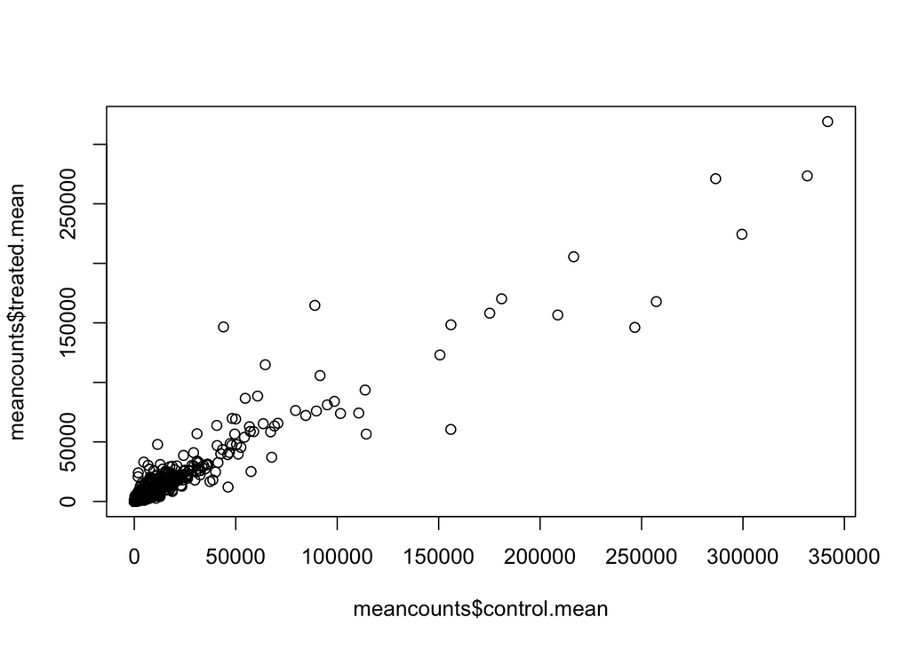

```r
plot(meancounts$control.mean,meancounts$treated.mean)
```

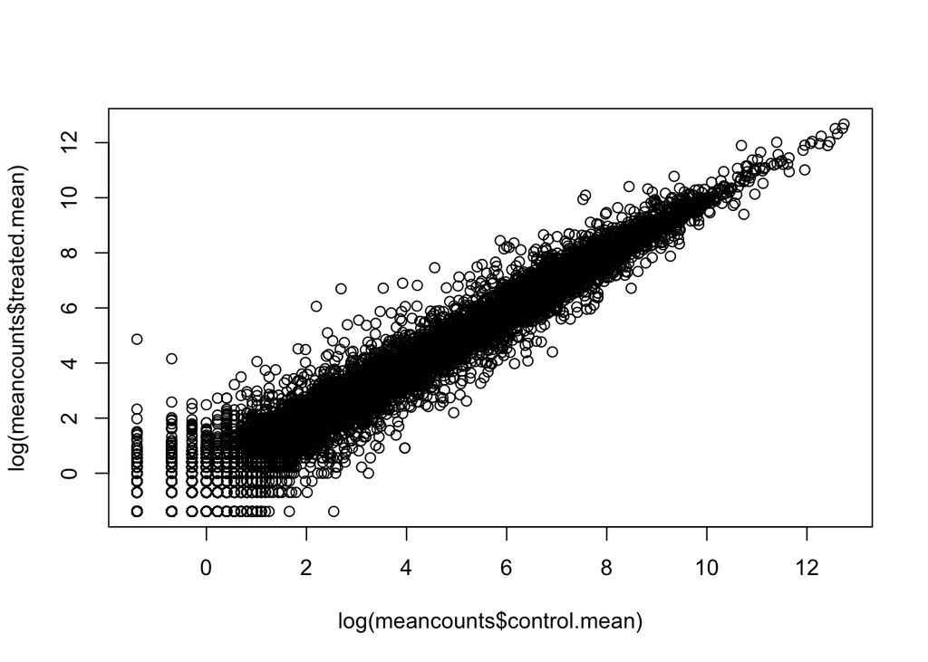

```r
plot(log(meancounts$control.mean), log(meancounts$treated.mean))
```

We can find candidate differentially expressed genes by looking for genes with a large change between control and dex-treated samples. We usually look at the log2 of the fold change, because this has better mathematical properties.

Here we calculate log2foldchange, add it to our meancounts data.frame and inspect the results either with the head() or the View() function for example.

```r
meancounts$log2fc <- log2(meancounts[,"treated.mean"]/meancounts[,"control.mean"])
head(meancounts)
```

```
##                 control.mean treated.mean      log2fc
## ENSG00000000003       900.75       658.00 -0.45303916
## ENSG00000000005         0.00         0.00         NaN
## ENSG00000000419       520.50       546.00  0.06900279
## ENSG00000000457       339.75       316.50 -0.10226805
## ENSG00000000460        97.25        78.75 -0.30441833
## ENSG00000000938         0.75         0.00        -Inf
```

```r
toy <- c(1,2,0,4,0)
toy == 0
```

```
## [1] FALSE FALSE  TRUE FALSE  TRUE
```

```r
which(toy == 0 )
```

```
## [1] 3 5
```

```r
toy <- meancounts[1:6,]
toy[,1:2]
```

```
##                 control.mean treated.mean
## ENSG00000000003       900.75       658.00
## ENSG00000000005         0.00         0.00
## ENSG00000000419       520.50       546.00
## ENSG00000000457       339.75       316.50
## ENSG00000000460        97.25        78.75
## ENSG00000000938         0.75         0.00
```

```r
which(toy[,1:2] == 0, arr.ind = TRUE)
```

```
##                 row col
## ENSG00000000005   2   1
## ENSG00000000005   2   2
## ENSG00000000938   6   2
```

```r
unique(which(toy[,1:2] == 0, arr.ind = TRUE)[,1])
```

```
## [1] 2 6
```

Remove the zero entry genes from meancounts to produce **mycounts**

```r
zero.vals <- which(meancounts[,1:2]==0, arr.ind=TRUE)

to.rm <- unique(zero.vals[,1])
mycounts <- meancounts[-to.rm,]
head(mycounts)
```

```
##                 control.mean treated.mean      log2fc
## ENSG00000000003       900.75       658.00 -0.45303916
## ENSG00000000419       520.50       546.00  0.06900279
## ENSG00000000457       339.75       316.50 -0.10226805
## ENSG00000000460        97.25        78.75 -0.30441833
## ENSG00000000971      5219.00      6687.50  0.35769358
## ENSG00000001036      2327.00      1785.75 -0.38194109
```

```r
up.ind <- mycounts$log2fc > 2
down.ind <- mycounts$log2fc < (-2)
```

```r
sum(up.ind)
```

```
## [1] 250
```

should get *250*

```r
sum(down.ind)
```

```
## [1] 367
```

```r
head(mycounts[up.ind,])
```

```
##                 control.mean treated.mean   log2fc
## ENSG00000004799       270.50      1429.25 2.401558
## ENSG00000006788         2.75        19.75 2.844349
## ENSG00000008438         0.50         2.75 2.459432
## ENSG00000011677         0.50         2.25 2.169925
## ENSG00000015413         0.50         3.00 2.584963
## ENSG00000015592         0.50         2.25 2.169925
```

## Adding annotation data

Use the **merge()** function to add annotation data from ensemble

```r
anno <- read.csv("data/annotables_grch38.csv")
head(anno)
```

```
##           ensgene entrez   symbol chr     start       end strand
## 1 ENSG00000000003   7105   TSPAN6   X 100627109 100639991     -1
## 2 ENSG00000000005  64102     TNMD   X 100584802 100599885      1
## 3 ENSG00000000419   8813     DPM1  20  50934867  50958555     -1
## 4 ENSG00000000457  57147    SCYL3   1 169849631 169894267     -1
## 5 ENSG00000000460  55732 C1orf112   1 169662007 169854080      1
## 6 ENSG00000000938   2268      FGR   1  27612064  27635277     -1
##          biotype
## 1 protein_coding
## 2 protein_coding
## 3 protein_coding
## 4 protein_coding
## 5 protein_coding
## 6 protein_coding
##                                                                                                  description
## 1                                                          tetraspanin 6 [Source:HGNC Symbol;Acc:HGNC:11858]
## 2                                                            tenomodulin [Source:HGNC Symbol;Acc:HGNC:17757]
## 3 dolichyl-phosphate mannosyltransferase polypeptide 1, catalytic subunit [Source:HGNC Symbol;Acc:HGNC:3005]
## 4                                               SCY1-like, kinase-like 3 [Source:HGNC Symbol;Acc:HGNC:19285]
## 5                                    chromosome 1 open reading frame 112 [Source:HGNC Symbol;Acc:HGNC:25565]
## 6                          FGR proto-oncogene, Src family tyrosine kinase [Source:HGNC Symbol;Acc:HGNC:3697]
```

```r
mycounts.annotated <- merge(x=mycounts, y=anno, by.x = "row.names", by.y ="ensgene")
head(mycounts.annotated)
```

```
##         Row.names control.mean treated.mean      log2fc entrez   symbol
## 1 ENSG00000000003       900.75       658.00 -0.45303916   7105   TSPAN6
## 2 ENSG00000000419       520.50       546.00  0.06900279   8813     DPM1
## 3 ENSG00000000457       339.75       316.50 -0.10226805  57147    SCYL3
## 4 ENSG00000000460        97.25        78.75 -0.30441833  55732 C1orf112
## 5 ENSG00000000971      5219.00      6687.50  0.35769358   3075      CFH
## 6 ENSG00000001036      2327.00      1785.75 -0.38194109   2519    FUCA2
##   chr     start       end strand        biotype
## 1   X 100627109 100639991     -1 protein_coding
## 2  20  50934867  50958555     -1 protein_coding
## 3   1 169849631 169894267     -1 protein_coding
## 4   1 169662007 169854080      1 protein_coding
## 5   1 196651878 196747504      1 protein_coding
## 6   6 143494811 143511690     -1 protein_coding
##                                                                                                  description
## 1                                                          tetraspanin 6 [Source:HGNC Symbol;Acc:HGNC:11858]
## 2 dolichyl-phosphate mannosyltransferase polypeptide 1, catalytic subunit [Source:HGNC Symbol;Acc:HGNC:3005]
## 3                                               SCY1-like, kinase-like 3 [Source:HGNC Symbol;Acc:HGNC:19285]
## 4                                    chromosome 1 open reading frame 112 [Source:HGNC Symbol;Acc:HGNC:25565]
## 5                                                     complement factor H [Source:HGNC Symbol;Acc:HGNC:4883]
## 6                                          fucosidase, alpha-L- 2, plasma [Source:HGNC Symbol;Acc:HGNC:4008]
```

## DESeq2 analysis

Now we do this analysis properly with p-values!

```r
library(DESeq2)
dds <- DESeqDataSetFromMatrix(countData=counts,
                              colData=metadata,
                              design=~dex,
                              tidy=TRUE)
dds
```

```
## class: DESeqDataSet
## dim: 38694 8
## metadata(1): version
## assays(1): counts
## rownames(38694): ENSG00000000003 ENSG00000000005 ...
##   ENSG00000283120 ENSG00000283123
## rowData names(0):
## colnames(8): SRR1039508 SRR1039509 ... SRR1039520 SRR1039521
## colData names(4): id dex celltype geo_id
```

```r
dds <- DESeq(dds)
res <- results(dds)
head(res)
```

```
## log2 fold change (MLE): dex treated vs control
## Wald test p-value: dex treated vs control
## DataFrame with 6 rows and 6 columns
##                          baseMean     log2FoldChange             lfcSE
##                         <numeric>          <numeric>         <numeric>
## ENSG00000000003  747.194195359907   -0.3507029622814 0.168242083226488
## ENSG00000000005                 0                 NA                NA
## ENSG00000000419  520.134160051965  0.206107283859631 0.101041504450297
## ENSG00000000457  322.664843927049 0.0245270113332259 0.145133863747848
## ENSG00000000460   87.682625164828 -0.147142630021601 0.256995442048617
## ENSG00000000938 0.319166568913118  -1.73228897394308  3.49360097648095
##                               stat             pvalue              padj
##                          <numeric>          <numeric>         <numeric>
## ENSG00000000003  -2.08451390731582 0.0371134465286876 0.163017154198658
## ENSG00000000005                 NA                 NA                NA
## ENSG00000000419   2.03982793982463 0.0413674659636722 0.175936611069872
## ENSG00000000457  0.168995785682647  0.865799956261551 0.961682459668587
## ENSG00000000460 -0.572549570718713  0.566949713033353 0.815805192485639
## ENSG00000000938 -0.495846258804286  0.620002884826012                NA
```

```r
summary(res)
```

```
##
## out of 25258 with nonzero total read count
## adjusted p-value < 0.1
## LFC > 0 (up)       : 1564, 6.2%
## LFC < 0 (down)     : 1188, 4.7%
## outliers [1]       : 142, 0.56%
## low counts [2]     : 9971, 39%
## (mean count < 10)
## [1] see 'cooksCutoff' argument of ?results
## [2] see 'independentFiltering' argument of ?results
```

```r
res05 <- results(dds, alpha=0.05)
summary(res05)
```

```
##
## out of 25258 with nonzero total read count
## adjusted p-value < 0.05
## LFC > 0 (up)       : 1237, 4.9%
## LFC < 0 (down)     : 933, 3.7%
## outliers [1]       : 142, 0.56%
## low counts [2]     : 9033, 36%
## (mean count < 6)
## [1] see 'cooksCutoff' argument of ?results
## [2] see 'independentFiltering' argument of ?results
```

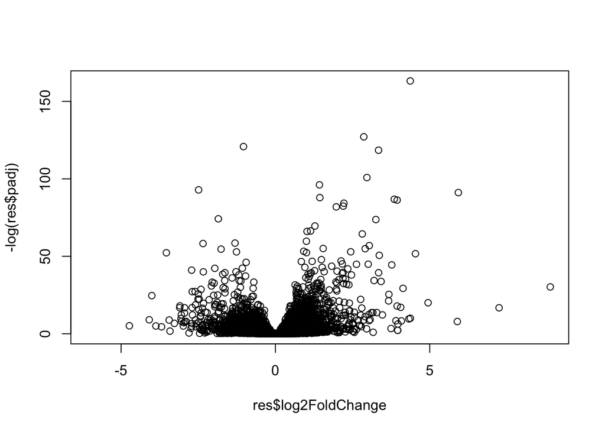

```r
plot(res$log2FoldChange, -log(res$padj))
```

```r
mycols <- rep("gray", nrow(res05))
mycols[abs(res05$log2FoldChange)]
```

[output not shown]

[output cut: 1948 more lines]

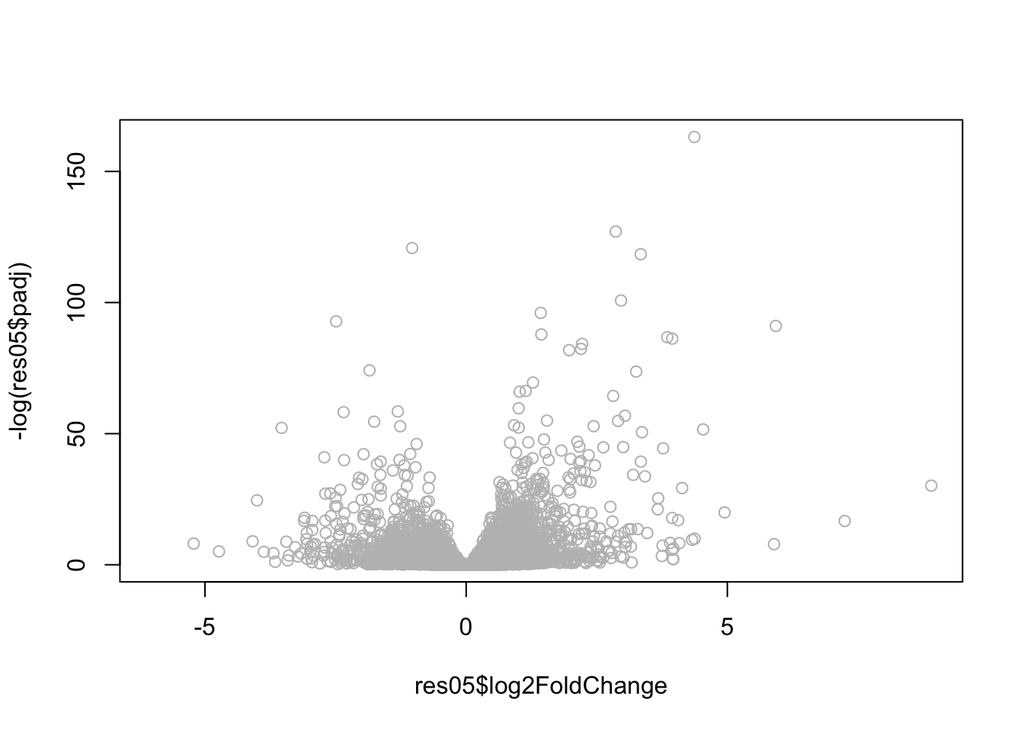

```r
plot(res05$log2FoldChange, -log(res05$padj), col=mycols)
```